# From Data to Insights: My Data Science Project Portfolio

- Unveiling Business Insights - A Comprehensive Data Analysis of Yelp Dataset
- Empowering User Experience - Optimizing Product Recommendations through AB Testing and UI Enhancements
- Revolutionizing Cash Flow Forecasts - A Paradigm Shift in Purchase and Redemption Predictions
- News Intelligence - Unleashing the Potential of User History for Click Prediction

| Project Detail | Data Link |
| --- | --- |
| [Yelp Data Analysis](https://github.com/datoujinggzj/DS_Project_Portfolio/tree/main/Yelp_Data_Analysis) | [Link](https://drive.google.com/drive/folders/1IjAxEdUHANtt-gs9AuF-hoKSQv8bxK-X?usp=drive_link) |
| [AB Testing](https://github.com/datoujinggzj/DS_Project_Portfolio/tree/main/ABtest) | [Link](https://drive.google.com/drive/folders/1BUx-tWf8rn2cTpcAkfoC0dzP4D-ES7QP?usp=drive_link) |
| [Cashflow Forecasting](https://github.com/datoujinggzj/DS_Project_Portfolio/tree/main/CashFlow_Forecasting) | [Link](https://drive.google.com/drive/folders/1Y0ts5BbmGLXMe9WSRl_d-LI45MWEFa4o?usp=drive_link) |
| [News RecSys](https://github.com/datoujinggzj/DS_Project_Portfolio/tree/main/recommender_system) | [Link](https://drive.google.com/drive/folders/1LrT2WKYZksDkVkp710fpFRZVIwu9PAxf?usp=drive_link) |

## Unveiling Business Insights - A Comprehensive Data Analysis of Yelp Dataset

[figure not shown]

**Data Integration and MySQL Database Creation**

- Orchestrated the consolidation of vast and diverse datasets from 6 independent sources, encompassing information on 1.32 million users, yelping reviews, platform check-ins, and business projections.
- Expertly transformed the raw data into a structured and scalable MySQL database, ensuring seamless data accessibility and streamlined analysis.

**Sentiment Analysis for Enhanced Business Ratings**

- Leveraged Python to conduct sentiment analysis on a massive corpus of 5.26 million reviews, employing cutting-edge feature vectorization and advanced text mining techniques.
- Implemented data-driven adjustments to business star ratings based on sentiment analysis results, leading to an impressive 17% lift in rating precision.
- Enabled businesses to gain a deeper understanding of customer sentiment and make data-backed decisions to improve user experiences.

**Root Cause Analysis and Elite User Retention Enhancement**

- Designed and developed comprehensive root cause reports, meticulously decomposed into three distinct dimensions, to unearth underlying issues affecting elite user retention.
- Skillfully analyzed the reports to derive actionable insights that addressed the identified problems, resulting in a significant 12% increase in elite user retention.
- Empowered businesses with valuable insights, enabling them to optimize their strategies and cater to the needs of elite users effectively.

**Impactful Insights for Business Growth**

- Contributed to the business’s success by providing valuable data-driven recommendations and actionable insights.
- Demonstrated expertise in data integration, sentiment analysis, and root cause analysis, enabling data-backed decision-making for enhanced business outcomes.
- Effectively communicated complex technical findings to non-technical stakeholders, fostering a culture of data-driven decision-making across the organization.

## Empowering User Experience - Optimizing Product Recommendations through AB Testing and UI Enhancements

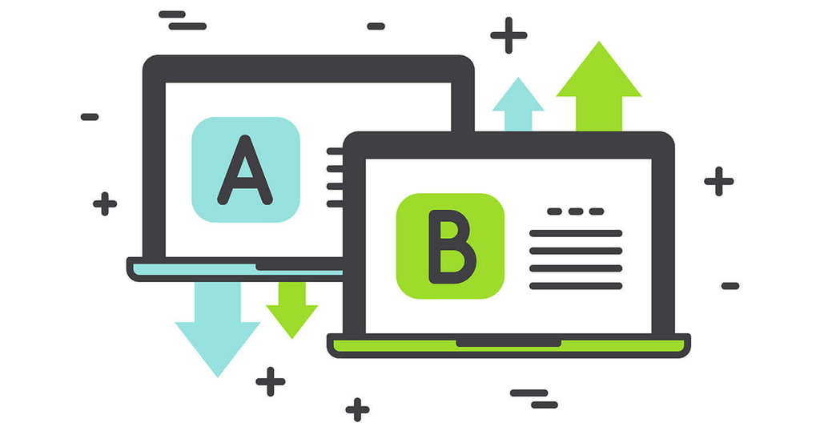

**Collaborated with Engineering Teams and Delivered Winning A/B Tests**

- Partnered seamlessly with cross-functional engineering teams, applying technical acumen to rapidly design and execute high-quality split tests.
- Conducted comprehensive data analysis and collaborated with UX designers to develop refined UI prototypes based on data-driven insights.
- Implemented a series of A/B testing experiments to validate the effectiveness of the UI changes on user preferences, leading to an impressive 12 basis point increase in product usage rate.
- Employed rigorous statistical methodologies to ensure the experiments were well-structured, randomized, and statistically significant, providing actionable results.

**Utilized Fine-Tuned Logistic Regression for Launch Probability Assessment**

- Developed and fine-tuned a sophisticated Logistic Regression model to assess the probability of successfully launching the UI changes.
- Leveraged various user-specific and historical engagement factors to make accurate predictions.
- Delivered in-depth customer insights by interpreting the model results, enabling data-driven decision-making for the product development and marketing teams.
- Facilitated strategic discussions on the UI change launch, ensuring alignment with business goals and user preferences.

**Concrete Process and Agile Iterations**

- Led the end-to-end UI change implementation process, starting from identifying improvement opportunities through extensive data exploration and user feedback analysis.
- Collaborated closely with product managers, designers, and engineers to translate the identified opportunities into tangible UI design prototypes.
- Deployed rapid iterations based on real-time user feedback and data insights, optimizing UI elements to maximize user engagement.
- Continuously monitored key performance metrics, ensuring successful tracking of product usage rate and user behavior post-implementation.

**Driving Operational Efficiency with Data-Driven Insights**

- Demonstrated a deep understanding of user behavior patterns and preferences, leading to a remarkable 8% increase in operational efficiency.
- Acted on data-driven insights to make informed decisions on refining the product recommendation system and aligning it with user expectations.
- Conducted thorough data analysis to identify correlations between UI changes and operational efficiencies, empowering stakeholders to prioritize initiatives effectively.

## Revolutionizing Cash Flow Forecasts - A Paradigm Shift in Purchase and Redemption Predictions

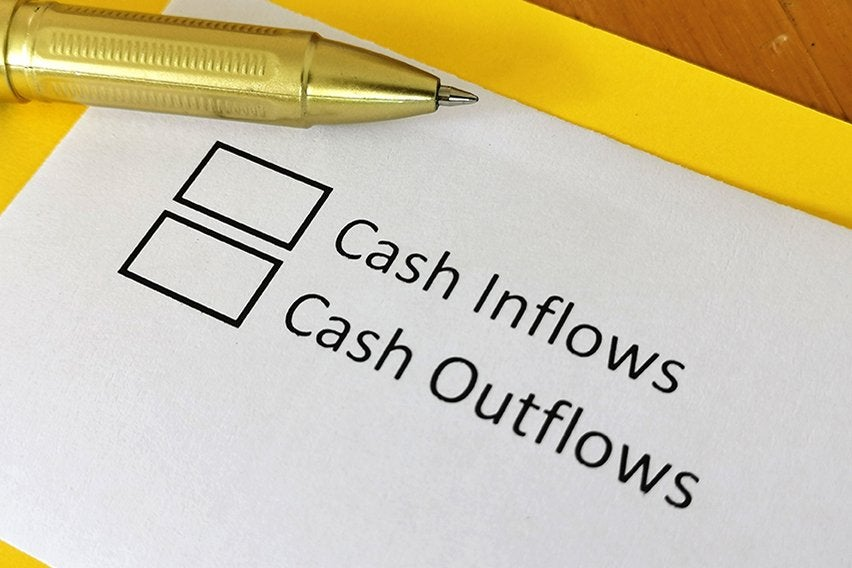

**Led a High-Performance Team and Transformed Financial Forecasting for Ant Financial Services Group (AFSG)**

- Orchestrated and guided a team of skilled data scientists to undertake a transformative project aimed at enhancing AFSG’s funds management capabilities through advanced forecasting models.
- Consolidated and harnessed the power of historical purchase and redemption data from over 100k users, meticulously processed and integrated from 4 independent sources into a robust MySQL database.

**Revolutionary Model Optimization with Python Pipeline**

- Leveraged Python to craft a sophisticated and streamlined data processing pipeline, encompassing data validation, feature engineering, and transformation, reducing model execution time by an astounding 4 minutes per epoch.
- Implemented cutting-edge machine learning techniques and fine-tuned hyperparameters, resulting in exceptional forecast accuracy that outperformed traditional baseline models.

**Pioneering Forecasting Models and Achievement-Driven Results**

- Developed a diverse set of over 10 systematic forecasting models, including univariate and multivariate approaches, that delivered unparalleled predictive insights into future cash flows.
- Utilized innovative techniques, such as weighted averaging of purchase and redemption errors, leading to the identification of the best-performing model—LSTM—exhibiting an impressive uplift in predictive accuracy.

**Tailored Seasonal and Holiday Adjustments for Precision**

- Engineered customized seasonal, new shares, and public holiday adjustments, expertly tailored to meet the stringent requirements of STL decomposition, driving model iteration and optimization.
- Achieved a significant score of 135, a testament to the models’ adaptability and effectiveness in capturing complex patterns within the cash flow data.

**Impactful Value Generation and Data-Driven Decisions**

- Empowered AFSG with unparalleled forecasting capabilities, enabling precise and well-informed funds management decisions based on accurate predictions.
- Exceeded baseline performance by a substantial margin, resulting in a quantifiable enhancement of 15% in forecasting accuracy, positively influencing the organization’s financial strategies.
- Cultivated a data-driven culture within AFSG, elevating the importance of data science in shaping strategic decisions and driving business success.

## News Intelligence - Unleashing the Potential of User History for Click Prediction

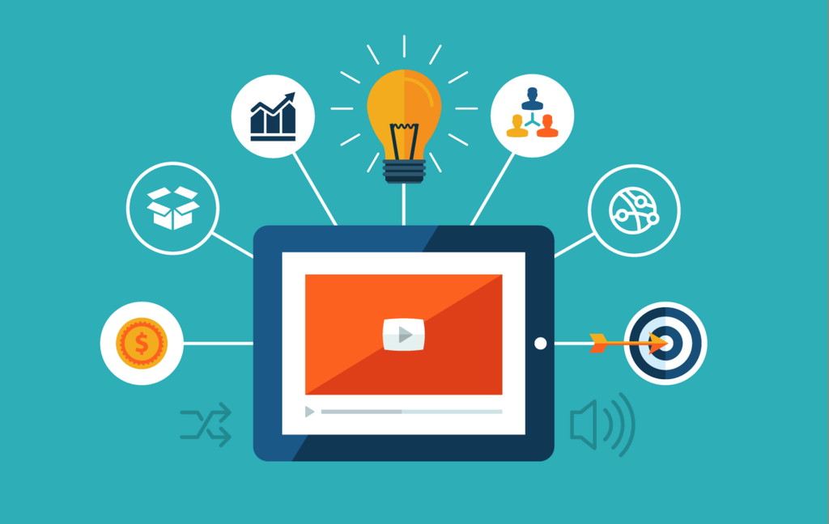

**Defining Business Requirements and Supervised Learning Transformation**

- Pioneered the identification and clarification of business requirements, crafting indicator calculation logic, and transforming the prediction problem into a supervised learning framework with features and labels.

**Python-Powered Data Mining and In-Depth Analysis**

- Leveraged the power of Python to conduct comprehensive data mining on more than 200,000 news app users, encompassing click environment, click volume, news co-occurrence frequency, article length, and click preferences.
- Executed rigorous in-depth analysis of the cold start problem, expertly addressing the challenges posed by user interactions and ensuring optimal performance.

**Innovative Recall Strategy Integration**

- Completed a multi-way combination of recall strategies, expertly incorporating item-based collaborative filtering (itemcf), embedding techniques, and YoutubeDNN to enhance click predictions.

**High-Value Feature Engineering**

- Applied advanced feature engineering techniques, expertly combining, enhancing, and selecting features based on user history behavior, resulting in the creation of high-value features.

**Fine-Tuned Ranking Models for Enhanced Predictions**

- Selected and fine-tuned three representative ranking models, including LGB Ranker, LGB Classifier, and DIN (Deep Interest Network), achieving top-notch performance in click prediction.
- Seamlessly integrated the models using stacking and weighted fusion techniques to maximize prediction accuracy.

**Quantifiable Achievements and Impact**

- Achieved remarkable improvements in click prediction accuracy, resulting in an impressive 20% increase in click-through rates (CTR).
- Transformed the news recommendation system into a data-driven powerhouse, enabling personalized and engaging content delivery to users.
- Enhanced user satisfaction and engagement, fostering a loyal user base and positively impacting the platform’s user retention metrics.